# Project Python Foundations: FoodHub Data Analysis

**Marks: 40**

### Context

The number of restaurants in New York is increasing day by day. Lots of students and busy professionals rely on those restaurants due to their hectic lifestyles. Online food delivery service is a great option for them. It provides them with good food from their favorite restaurants. A food aggregator company FoodHub offers access to multiple restaurants through a single smartphone app.

The app allows the restaurants to receive a direct online order from a customer. The app assigns a delivery person from the company to pick up the order after it is confirmed by the restaurant. The delivery person then uses the map to reach the restaurant and waits for the food package. Once the food package is handed over to the delivery person, he/she confirms the pick-up in the app and travels to the customer's location to deliver the food. The delivery person confirms the drop-off in the app after delivering the food package to the customer. The customer can rate the order in the app. The food aggregator earns money by collecting a fixed margin of the delivery order from the restaurants.

### Objective

The food aggregator company has stored the data of the different orders made by the registered customers in their online portal. They want to analyze the data to get a fair idea about the demand of different restaurants which will help them in enhancing their customer experience. Suppose you are hired as a Data Scientist in this company and the Data Science team has shared some of the key questions that need to be answered. Perform the data analysis to find answers to these questions that will help the company to improve the business.

### Data Description

The data contains the different data related to a food order. The detailed data dictionary is given below.

### Data Dictionary

- order_id: Unique ID of the order
- customer_id: ID of the customer who ordered the food
- restaurant_name: Name of the restaurant
- cuisine_type: Cuisine ordered by the customer
- cost: Cost of the order
- day_of_the_week: Indicates whether the order is placed on a weekday or weekend (The weekday is from Monday to Friday and the weekend is Saturday and Sunday)
- rating: Rating given by the customer out of 5
- food_preparation_time: Time (in minutes) taken by the restaurant to prepare the food. This is calculated by taking the difference between the timestamps of the restaurant's order confirmation and the delivery person's pick-up confirmation.
- delivery_time: Time (in minutes) taken by the delivery person to deliver the food package. This is calculated by taking the difference between the timestamps of the delivery person's pick-up confirmation and drop-off information

### Let us start by importing the required libraries

```python
# import libraries for data manipulation
import numpy as np
import pandas as pd

# import libraries for data visualization
import matplotlib.pyplot as plt
import seaborn as sns
%matplotlib inline
```

```python
import warnings
warnings.filterwarnings('ignore')
```

### Understanding the structure of the data

```python
# read the data
df = pd.read_csv('foodhub_order.csv')
# returns the first 5 rows
df.head()
```

|  | order_id | customer_id | restaurant_name | cuisine_type | cost_of_the_order | day_of_the_week | rating | food_preparation_time | delivery_time |
| --- | --- | --- | --- | --- | --- | --- | --- | --- | --- |
| 0 | 1477147 | 337525 | Hangawi | Korean | 30.75 | Weekend | Not given | 25 | 20 |
| 1 | 1477685 | 358141 | Blue Ribbon Sushi Izakaya | Japanese | 12.08 | Weekend | Not given | 25 | 23 |
| 2 | 1477070 | 66393 | Cafe Habana | Mexican | 12.23 | Weekday | 5 | 23 | 28 |
| 3 | 1477334 | 106968 | Blue Ribbon Fried Chicken | American | 29.20 | Weekend | 3 | 25 | 15 |
| 4 | 1478249 | 76942 | Dirty Bird to Go | American | 11.59 | Weekday | 4 | 25 | 24 |

#### Observations:

The DataFrame has 9 columns as mentioned in the Data Dictionary. Data in each row corresponds to the order placed by a customer.

### **Question 1:** Write the code to check the shape of the dataset and write your observations based on that. (0.5 mark)

```python
# write your code here
df.shape
```

```
(1898, 9)
```

#### Observations:

The dataset consists of 1898 records and 9 fields.

### Question 2: Write the observations based on the below output from the info() method. (0.5 mark)

```python
# use info() to print a concise summary of the DataFrame
df.info()
```

```
<class 'pandas.core.frame.DataFrame'>
RangeIndex: 1898 entries, 0 to 1897
Data columns (total 9 columns):
 #   Column                 Non-Null Count  Dtype
---  ------                 --------------  -----
 0   order_id               1898 non-null   int64
 1   customer_id            1898 non-null   int64
 2   restaurant_name        1898 non-null   object
 3   cuisine_type           1898 non-null   object
 4   cost_of_the_order      1898 non-null   float64
 5   day_of_the_week        1898 non-null   object
 6   rating                 1898 non-null   object
 7   food_preparation_time  1898 non-null   int64
 8   delivery_time          1898 non-null   int64
dtypes: float64(1), int64(4), object(4)
memory usage: 133.6+ KB
```

#### Observations:

The dataset does not have any null records. There are 4 columns of datatype object, 4 columns of integer and 1 column of float.

### Question 3: 'restaurant_name', 'cuisine_type', 'day_of_the_week' are object types. Write the code to convert the mentioned features to 'category' and write your observations on the same. (0.5 mark)

```python
# coverting "objects" to "category" reduces the data space required to store the dataframe
# write the code to convert 'restaurant_name', 'cuisine_type', 'day_of_the_week' into categorical data
df['restaurant_name'] = df['restaurant_name'].astype('category')
df['cuisine_type'] = df['cuisine_type'].astype('category')
df['day_of_the_week']= df['day_of_the_week'].astype('category')
# use info() to print a concise summary of the DataFrame
df.info()
```

```
<class 'pandas.core.frame.DataFrame'>
RangeIndex: 1898 entries, 0 to 1897
Data columns (total 9 columns):
 #   Column                 Non-Null Count  Dtype
---  ------                 --------------  -----
 0   order_id               1898 non-null   int64
 1   customer_id            1898 non-null   int64
 2   restaurant_name        1898 non-null   category
 3   cuisine_type           1898 non-null   category
 4   cost_of_the_order      1898 non-null   float64
 5   day_of_the_week        1898 non-null   category
 6   rating                 1898 non-null   object
 7   food_preparation_time  1898 non-null   int64
 8   delivery_time          1898 non-null   int64
dtypes: category(3), float64(1), int64(4), object(1)
memory usage: 102.7+ KB
```

#### Observations:

We changed datatype of the fields (resturant_name, cuisine_type and day_of_the_week) to category from object. This led to our memory usage reduction to 102.7 KB from 133.6 KB

### **Question 4:** Write the code to find the summary statistics and write your observations based on that. (1 mark)

```python
# write your code here
df.describe().round(3).T
```

|  | count | mean | std | min | 25% | 50% | 75% | max |
| --- | --- | --- | --- | --- | --- | --- | --- | --- |
| order_id | 1898.0 | 1477495.500 | 548.050 | 1476547.00 | 1477021.25 | 1477495.50 | 1477969.750 | 1478444.00 |
| customer_id | 1898.0 | 171168.478 | 113698.140 | 1311.00 | 77787.75 | 128600.00 | 270525.000 | 405334.00 |
| cost_of_the_order | 1898.0 | 16.499 | 7.484 | 4.47 | 12.08 | 14.14 | 22.298 | 35.41 |
| food_preparation_time | 1898.0 | 27.372 | 4.632 | 20.00 | 23.00 | 27.00 | 31.000 | 35.00 |
| delivery_time | 1898.0 | 24.162 | 4.973 | 15.00 | 20.00 | 25.00 | 28.000 | 33.00 |

#### Observations:

We observe that average food order cost is \$16.5 Most of the data lie close to the median cost of order of USD 14.14 as shown by 25th and 75th percentile cost of order. It takes in an average of 27.37 minutes to prepare an order and another 24.16 minutes to deliver to the customer, which is a significant wait time for the customer. At the peak periods indicated by 75th percentile, that time extends to 31 minutes of preparation and another 28 minutes of delivery time (not to imply that these two events occur together). We also see that the fastest a delivery was made was in 15 minutes.

```python
df['total_time_to_deliver']= df['food_preparation_time']+ df['delivery_time']
```

```python
df.head()
```

|  | order_id | customer_id | restaurant_name | cuisine_type | cost_of_the_order | day_of_the_week | rating | food_preparation_time | delivery_time | total_time_to_deliver |
| --- | --- | --- | --- | --- | --- | --- | --- | --- | --- | --- |
| 0 | 1477147 | 337525 | Hangawi | Korean | 30.75 | Weekend | Not given | 25 | 20 | 45 |
| 1 | 1477685 | 358141 | Blue Ribbon Sushi Izakaya | Japanese | 12.08 | Weekend | Not given | 25 | 23 | 48 |
| 2 | 1477070 | 66393 | Cafe Habana | Mexican | 12.23 | Weekday | 5 | 23 | 28 | 51 |
| 3 | 1477334 | 106968 | Blue Ribbon Fried Chicken | American | 29.20 | Weekend | 3 | 25 | 15 | 40 |
| 4 | 1478249 | 76942 | Dirty Bird to Go | American | 11.59 | Weekday | 4 | 25 | 24 | 49 |

```python
df.describe().round(3)
```

|  | order_id | customer_id | cost_of_the_order | food_preparation_time | delivery_time | total_time_to_deliver |
| --- | --- | --- | --- | --- | --- | --- |
| count | 1898.00 | 1898.000 | 1898.000 | 1898.000 | 1898.000 | 1898.000 |
| mean | 1477495.50 | 171168.478 | 16.499 | 27.372 | 24.162 | 51.534 |
| std | 548.05 | 113698.140 | 7.484 | 4.632 | 4.973 | 6.834 |
| min | 1476547.00 | 1311.000 | 4.470 | 20.000 | 15.000 | 35.000 |
| 25% | 1477021.25 | 77787.750 | 12.080 | 23.000 | 20.000 | 47.000 |
| 50% | 1477495.50 | 128600.000 | 14.140 | 27.000 | 25.000 | 52.000 |
| 75% | 1477969.75 | 270525.000 | 22.298 | 31.000 | 28.000 | 56.000 |
| max | 1478444.00 | 405334.000 | 35.410 | 35.000 | 33.000 | 68.000 |

### **Question 5:** How many orders are not rated? (0.5 mark)

```python
df['rating'].value_counts()
```

```
Not given    736
5            588
4            386
3            188
Name: rating, dtype: int64
```

#### Observations:

736 orders were not rated.

### Exploratory Data Analysis (EDA)

### **Question 6:** Explore all the variables and provide observations on the distributions of all the relevant variables in the dataset. (5 marks)

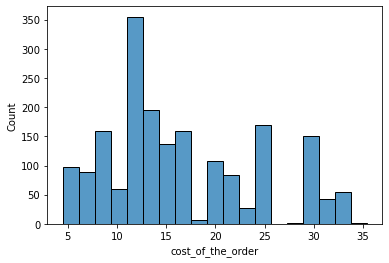

```python
sns.histplot(df['cost_of_the_order']);
```

### Observation

Here we can see the the average cost of food is around $15. That's where most orders cost lie around.

```python
df.groupby(['day_of_the_week'])['cost_of_the_order'].sum()
```

```
day_of_the_week
Weekday     8922.22
Weekend    22392.60
Name: cost_of_the_order, dtype: float64
```

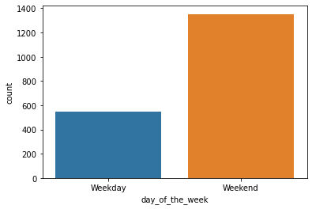

```python
sns.countplot(df['day_of_the_week']);
```

### Observation

Weekends are more popular to order food than on weekdays.

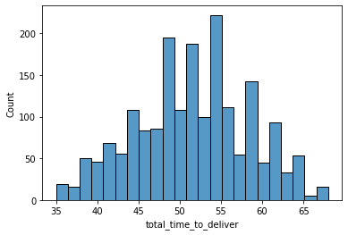

```python
sns.histplot(data=df, x='total_time_to_deliver');
```

### Observation

-Average total time to deliver food starting from preparing to the customer's door is at around 52 minutes. The distribution is largely normally distributed.

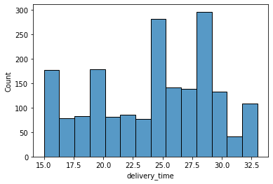

```python
sns.histplot(data=df, x='delivery_time');
```

### Observation

- Here we can see the time to deliver to the customer's door is slightly left skewed.

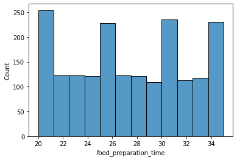

```python
sns.histplot(data=df, x='food_preparation_time');
```

### Observation

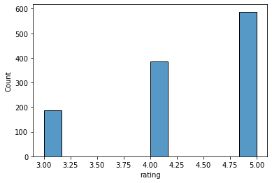

```python
sns.histplot(data=df, x='rating');
```

### Observation

5 rated orders are of highest count followed by 4 and 3 rated.

### Question 7: Write the code to find the top 5 restaurants that have received the highest number of orders. (1 mark)

```python
# write the code here
top_restaurants= pd.DataFrame(df['restaurant_name'].value_counts()[0:5])
top_restaurants
```

|  | restaurant_name |
| --- | --- |
| Shake Shack | 219 |
| The Meatball Shop | 132 |
| Blue Ribbon Sushi | 119 |
| Blue Ribbon Fried Chicken | 96 |
| Parm | 68 |

#### Observation

Top five selling restaurants are Shake Shack, The Meatball Shop, Blue Ribbon Sushi, Blue Ribbon Fried Chicken and Parm

### Question 8: Write the code to find the most popular cuisine on weekends. (1 mark)

```python
# write the code here
pop_cuisine= pd.DataFrame(df.groupby(['day_of_the_week'])['cuisine_type'].value_counts())
pop_cuisine
```

| day_of_the_week | cuisine_type | cuisine_type |
| --- | --- | --- |
| Weekday | American | 169 |
|  | Japanese | 135 |
|  | Italian | 91 |
|  | Chinese | 52 |
|  | Indian | 24 |
|  | Mexican | 24 |
|  | Middle Eastern | 17 |
|  | Mediterranean | 14 |
|  | Southern | 6 |
|  | French | 5 |
|  | Thai | 4 |
|  | Vietnamese | 3 |
|  | Korean | 2 |
|  | Spanish | 1 |
| Weekend | American | 415 |
|  | Japanese | 335 |
|  | Italian | 207 |
|  | Chinese | 163 |
|  | Mexican | 53 |
|  | Indian | 49 |
|  | Mediterranean | 32 |
|  | Middle Eastern | 32 |
|  | Thai | 15 |
|  | French | 13 |
|  | Korean | 11 |
|  | Southern | 11 |
|  | Spanish | 11 |
|  | Vietnamese | 4 |

#### Observations:

American food is most popular in weekends as it is ordered 415 times throughout.

### Question 9: Write the code to find the number of total orders where the cost is above 20 dollars. What is the percentage of such orders in the dataset? (1 mark)

```python
# write the code here
max_count= df[df['cost_of_the_order']>20]['cost_of_the_order'].count()
total_orders= df['cost_of_the_order'].count()
percent= (max_count/total_orders*100).round(2)
print('Total number of orders where cost is above 20 dollars is', max_count)
print('Percentage of orders that cost above 20 dollars in dataset is', percent,'%')
```

```
Total number of orders where cost is above 20 dollars is 555
Percentage of orders that cost above 20 dollars in dataset is 29.24 %
```

#### Observations:

There are 555 orders that cost more than $20 and percentage of orders that cost above 20 dollats in dataset is 29.24%

### Question 10: Write the code to find the mean delivery time based on this dataset. (1 mark)

```python
# write the code here
df['delivery_time'].mean()
```

```
24.161749209694417
```

#### Observations:

It takes about 24 minutes to deliver the food to the customer.

### Question 11: Suppose the company has decided to give a free coupon of 15 dollars to the customer who has spent the maximum amount on a single order. Write the code to find the ID of the customer along with the order details. (1 mark)

```python
df.loc[df['cost_of_the_order'].idxmax()]
```

```
order_id                       1477814
customer_id                      62359
restaurant_name                  Pylos
cuisine_type             Mediterranean
cost_of_the_order                35.41
day_of_the_week                Weekday
rating                               4
food_preparation_time               21
delivery_time                       29
total_time_to_deliver               50
Name: 573, dtype: object
```

#### Observations:

ID of the customer who spent maximum amount on a single order is 62359. The food cost $35.41 and was of mediterranean cuisine type. The order was made on a weekday and was rated a 4.

### Question 12: Perform bivariate/multivariate analysis to explore relationships between the important variables in the dataset. (7 marks)

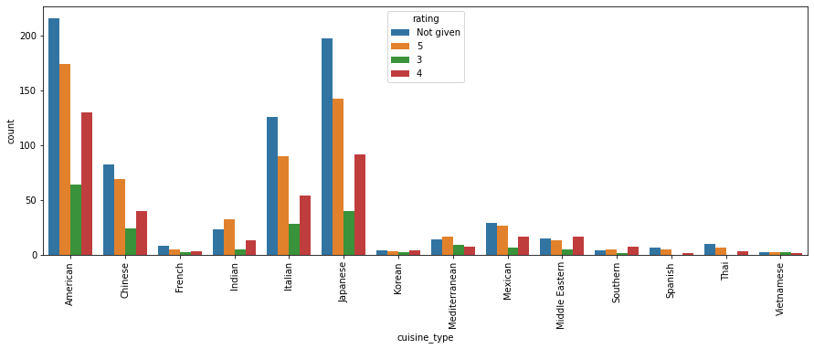

```python
plt.figure(figsize= (15,5))
sns.countplot(data=df, x='cuisine_type', hue= 'rating');
plt.xticks(rotation=90)
plt.show()
```

### Observation

It appears that American, Italian and Japanese food are favoured most. Those cuisines are ordered the most and rated high in comparison to other cuisines

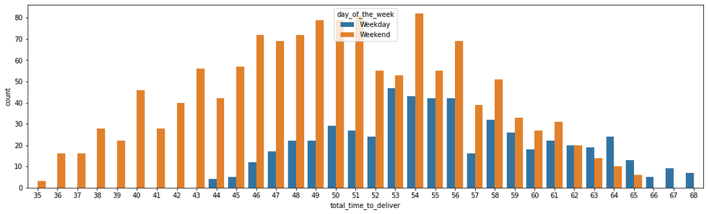

```python
plt.figure(figsize= (18,5))
sns.countplot(data= df, x='total_time_to_deliver', hue= 'day_of_the_week');
```

### Observation

The time to deliver the order starting from preparing food to the customers' order takes in an average of 51 minutes. In the following graphs we can break down the time into preparing and delivering.

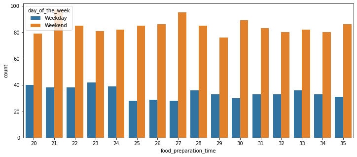

```python
plt.figure(figsize= (12,5))
sns.countplot(data= df, x='food_preparation_time', hue= 'day_of_the_week');
```

### Observation:

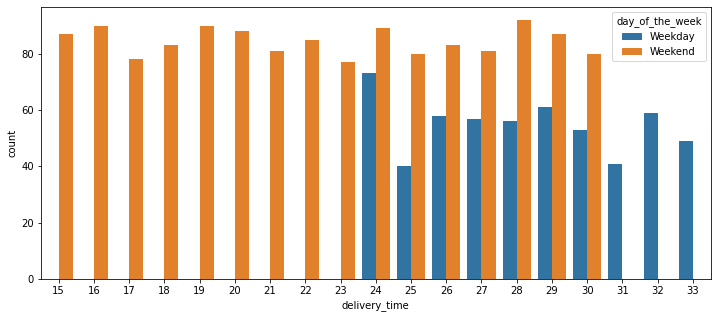

```python
plt.figure(figsize= (12,5))
sns.countplot(data= df, x='delivery_time', hue= 'day_of_the_week');
```

We see that deliveries during weekend are faster and on weekdays it takes more time to deliver the food to customer

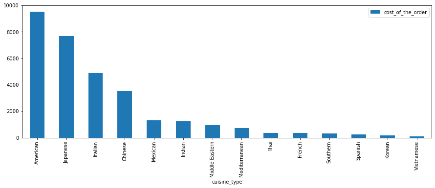

```python
df.groupby(by=['cuisine_type'])['cost_of_the_order'].sum().reset_index().sort_values(['cost_of_the_order'],ascending=False).plot(x='cuisine_type',
                                                                                                                 y='cost_of_the_order',
                                                                                                                 kind= 'bar',
                                                                                                                 figsize=(15,5));
```

### Observation

American food are ordered the most followed by japanese and italian, and vietnamese foods are ordered least.

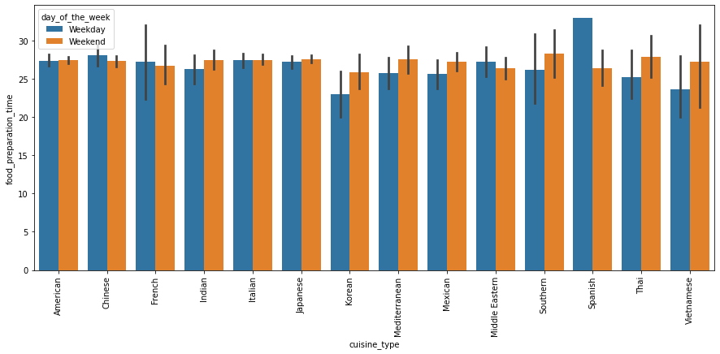

```python
plt.figure(figsize= (15,6))
sns.barplot(data=df, x='cuisine_type', y= 'food_preparation_time', hue= 'day_of_the_week')
plt.xticks(rotation=90)
plt.show();
```

### Observation

It pretty much takes similar amount of time to prepare the food, however, it appears spanish foods take more time to get ready on weekdays. Korean and vietnamese foods are prepared faster than other cuisines. Drivers can plan accordingly.

### Question 13: Suppose the company wants to provide a promotional offer in the advertisement of the restaurants. The condition to get the offer is that the restaurants must have a rating count of more than 50 and the average rating should be greater than 4. Write the code to find the restaurants fulfilling the criteria to get the promotional offer. (2 marks)

```python
# # write the code here
df['rating'].replace('Not given', np.nan, inplace= True)
df['rating']= df['rating'].astype(float)
rating_count= pd.DataFrame(df.groupby('restaurant_name')['rating'].agg(['mean','count']))
rating_count[(rating_count['count']>50) & (rating_count['mean']>4)]
```

| restaurant_name | mean | count |
| --- | --- | --- |
| Blue Ribbon Fried Chicken | 4.328125 | 64 |
| Blue Ribbon Sushi | 4.219178 | 73 |
| Shake Shack | 4.278195 | 133 |
| The Meatball Shop | 4.511905 | 84 |

#### Observations:

There are 4 restaurants of rating higher than 4 with rating count more than 50.